class: inverse, center, middle # Latch

# Latch

.fl.w-60.pa2[ ##¿Qué es un Latch? - Es el elemento base de los circuitos secuenciales. - Permiten almacenar temporalmente un bit de información - Necesitan de alimentación para mantener la información - Son utilices para construir circuitos asíncronos. - No dependen de un reloj - Empaquetados en CI.]

.fl.w-40.pa2[

[figure not shown]

SN74LS75. Latch tipo D cuadruple. SN74LS75 - datasheet TI

# Latch SR con puertas NOR

.fl.w-60.pa2[

[figure not shown]

Esquema de circuito Latch SR utilizando puertas NOR.

]

.panelset[.panel[.panel-name[Desarrollo]

| Entrada S | Entrada R | Salida $Q$ | Salida $\bar{Q}$ | Salida Comentario |
| --- | --- | --- | --- | --- |
| 1 | 0 |  |  |  |
| 0 | 0 |  |  |  |
| 0 | 1 |  |  |  |
| 0 | 0 |  |  |  |
| 1 | 1 |  |  |  |

]

.panel[.panel-name[Resp] .fl.w-40.pa2[

| Entrada S | Entrada R | Salida $Q$ | Salida $\bar{Q}$ | Salida Comentario |
| --- | --- | --- | --- | --- |
| 1 | 0 | 1 | 0 | Establecer |
| 0 | 0 | 1 | 0 | Mantener |
| 0 | 1 | 0 | 1 | Reset |
| 0 | 0 | 0 | 1 | Mantener |
| 1 | 1 | 0 | 0 | Indeterminación |

.bg-washed-green.b–dark-green.shadow-5[ El estado $Q(t+1)$ depende del estado anterior $Q(t)$] ]]]

???

| Entrada |  | Salida |  |  |
| --- | --- | --- | --- | --- |
| 1 | 0 | 1 | 0 | Establecer |
| 0 | 0 | 1 | 0 | Mantener |
| 0 | 1 | 0 | 1 | Reset |
| 0 | 0 | 0 | 1 | Mantener |
| 1 | 1 | 0 | 0 | Indeterminación |

# Latch SR con puertas NOR 2

.fl.w-60.pa2.font80[

| Entrada $S$ | Entrada $R$ | Salida $Q$ | Salida $\bar{Q}$ | Comentario |
| --- | --- | --- | --- | --- |
| 1 | 0 | 1 | 0 | Almacena S en Q |
| 0 | 0 | 1 | 0 | Mantiene el valor de Q |
| 0 | 1 | 0 | 1 | Restablece el valor de Q |
| 0 | 0 | 0 | 1 | Mantiene el valor de Q |
| 1 | 1 | 0 | 0 | Estado no permitido |

[figure not shown]

] .fl.w-40.pa2.font90[ - Poseen dos entrada - S = **S**et (Establecimiento o Selección) - R = **R**eset (Restablecimiento o Reset)

- Problema:
  - Estado no permitido $𝑄=\bar{Q}$ ]

# Tabla de función

.fl.w-50.pa2.font80[

| Entrada $S$ | Entrada $R$ | Salida $Q$ | Salida $\bar{Q}$ | Comentario |
| --- | --- | --- | --- | --- |
| 1 | 0 | 1 | 0 | Almacena S en Q |
| 0 | 0 | 1 | 0 | Mantiene el valor de Q |
| 0 | 1 | 0 | 1 | Restablece el valor de Q |
| 0 | 0 | 0 | 1 | Mantiene el valor de Q |
| 1 | 1 | 0 | 0 | Estado no permitido |

[figure not shown]

] .fl.w-50.pa2.font80[

| Entrada $S$ | Entrada $R$ | Salida $Q(t+1)$ | Comentario |
| --- | --- | --- | --- |
| 1 | 0 | 1 | Almacena S en Q |
| 0 | 0 | Q(t) | Mantiene el valor de Q |
| 0 | 1 | 0 | Restablece el valor de Q |
| 1 | 1 | No permitido | Estado no permitido |

]

# Latch SR con puertas NAND

.fl.w-60.pa2[

[figure not shown]

latch SR construido mediante puertas NAND

]

.fl.w-40.pa2[ .panelset[.panel[.panel-name[Desarrollo]

| Entrada $\bar{S}$ | Entrada $\bar{R}$ | Salida $Q(t+1)$ | Salida Comentario |
| --- | --- | --- | --- |
| 1 | 0 |  |  |
| 1 | 1 |  |  |
| 0 | 1 |  |  |
| 1 | 1 |  |  |
| 0 | 0 |  |  |

]

.panel[.panel-name[Resp]

[output not shown]

]]] ???

[output not shown]

# Latch SR con puertas NAND 2

.fl.w-40.pa2[ ¿Qué hace especial esta configuración de puertas lógicas?

[figure not shown]

latch SR construido mediante puertas NAND

]

.fl.w-60.pa2[ .panelset[.panel[.panel-name[Desarrollo]] .panel[.panel-name[Resp]

[figure not shown]

No es más que un circuito con realimentación entre la puerta NAND2 y la puerta NAND1

] ] ] ???

[figure not shown]

# Aplicación Latch SR

.fl.w-40.pa2[

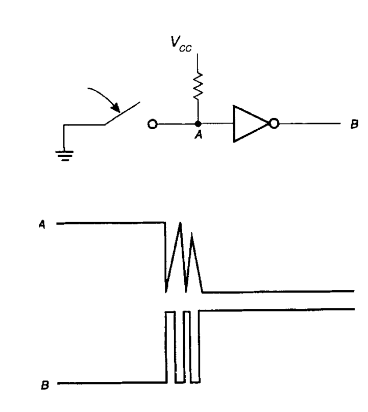

Oscilación generada por un interruptor conectado a un circuito digital. Electrónica digital - J. W. Bignell

]

–

.fl.w-60.pa2[

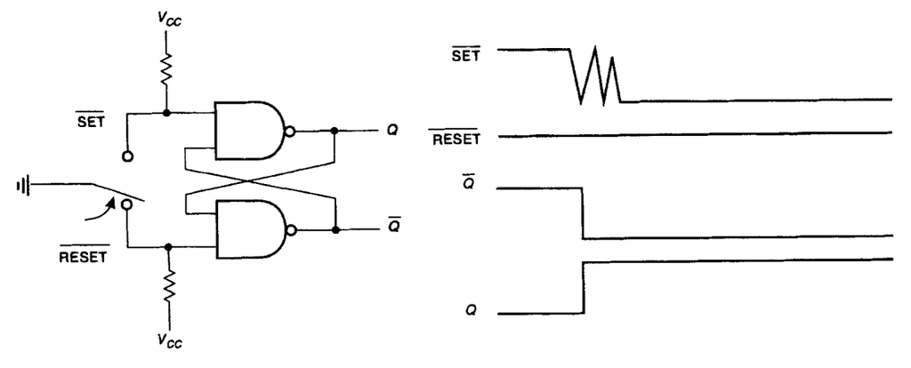

]

# Latch SR con entrada de control

.fl.w-60.pa2[

[figure not shown]

Latch RS NAND con entrada de control

] .fl.w-40.pa2[

[output not shown]

]

# Latch D

.fl.w-60.pa2[

[figure not shown]

Circuito Latch D

] .fl.w-40.pa2[

Tabla caracteristica Latch D

| C | D | $Q(t+1)$ |  |
| --- | --- | --- | --- |
| 0 | $X$ | $Q(t)$ | Sin cambios |
| 1 | 0 | 0 | Restablece |
| 1 | 1 | 1 | Establece |

]

# Aplicación Latch D

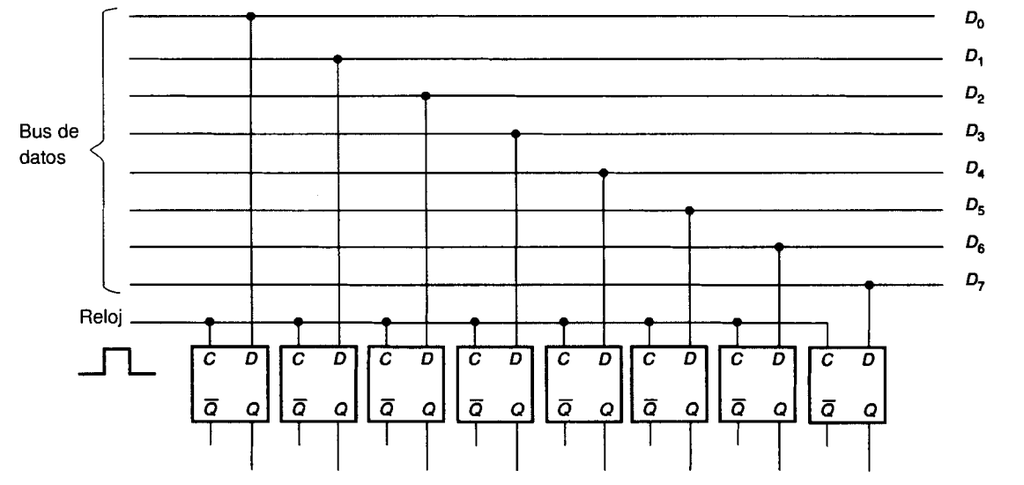

Almacenamiento de buses de datos - Electrónica digital - J. W. Bignell

[output not shown]

# Simbología Latch

[figure not shown]

— # Señal de reloj - Lógica secuencial síncrona/asíncrona

[figure not shown]

Forma de onda y señal de reloj. Sistemas Digitales - Ronald J. Tocci

# Problema con los Latch

.fl.w-50.pa2[

[figure not shown]

.fl.w-50.pa2[

[figure not shown]

] .fl.w-50.pa2[

| C | D | $Q(t+1)$ |
| --- | --- | --- |
| 0 | $X$ | $Q(t)$ |
| 1 | 0 | 0 |
| 1 | 1 | 1 |

]]

.fl.w-50.pa2[

[figure not shown]

]

# Problema con los Latch 2

.fl.w-50.pa2[

[figure not shown]

.fl.w-50.pa2[

[figure not shown]

] .fl.w-50.pa2[

| C | D | $Q(t+1)$ |
| --- | --- | --- |
| 0 | $X$ | $Q(t)$ |
| 1 | 0 | 0 |
| 1 | 1 | 1 |

]]

.fl.w-50.pa2[

[figure not shown]

]

# Problema con los Latch 3

.fl.w-50.pa2[

[figure not shown]

Diseño digital - Morris Mano

]

.fl.w-50.pa2[ - El uso del nivel positivo de la señal tiene que ser cambiado. - Usar mejor el flanco de subida/bajada. - Los Flip-Flop son arreglos de Latch que permiten utilizar los “bordes” (flancos) de la señal de reloj para controlar las señales]